# VeRUS: Verification of Reference Intervals Based on the Uncertainty of Sampling

### Non-Default Parameters to Define Uncertainty Margins

By default, the uncertainty margins approximate the 90% confidence intervals expected when estimating the population quantiles *RIperc* with a sample size of 120 which is the minimum sample size recommended for the non-parametric direct approach of establishing RIs. The width of the uncertainty margins can be adjusted with the parameters:

- *n* (*integer*) indicating the sample size for which the sampling uncertainty shall be taken into account. Default is 120
- *UMprop* (*numeric*) defining the desired confidence level for the uncertainty margins. Default is 0.9 (90% approximated confidence interval).

```r
verifyRI(RIdata = custom_RWDRI, RIcand = c(9.1, 31.5), title = "n=120, UMprop=0.9")
```

```
##
##  Verification of Reference Interval [VeRUS]
## ------------------------------------------
##
## Verification result: TEST NOT PASSED
##
## Perc  | RI Data           | RI Cand           | Overlap
## ----- | ----------------- | ----------------- | ------------------
##  2.5% | 13.2 (10.6; 15.8) |  9.1 (   7; 11.3) | Overlap of margins
## 97.5% | 40.3 (37.4; 43.2) | 31.5 (29.1; 33.9) |         No overlap
```

```r
# increasing n may be desired to get a more strict verification
verifyRI(RIdata = custom_RWDRI, RIcand = c(9.1, 31.5), n = 1000, UMprop = 0.95, title = "n=1000, UMprop=0.95")
```

```
##
##  Verification of Reference Interval [VeRUS]
## ------------------------------------------
##
## Verification result: TEST NOT PASSED
##
## Perc  | RI Data           | RI Cand           | Overlap
## ----- | ----------------- | ----------------- | ----------
##  2.5% | 13.2 (12.1; 14.3) |  9.1 (8.23; 9.98) | No overlap
## 97.5% | 40.3 (39.1; 41.5) | 31.5 (30.5; 32.5) | No overlap
```

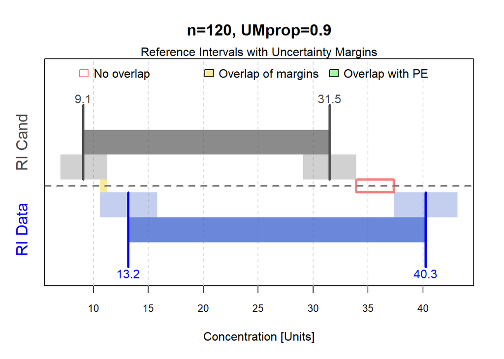

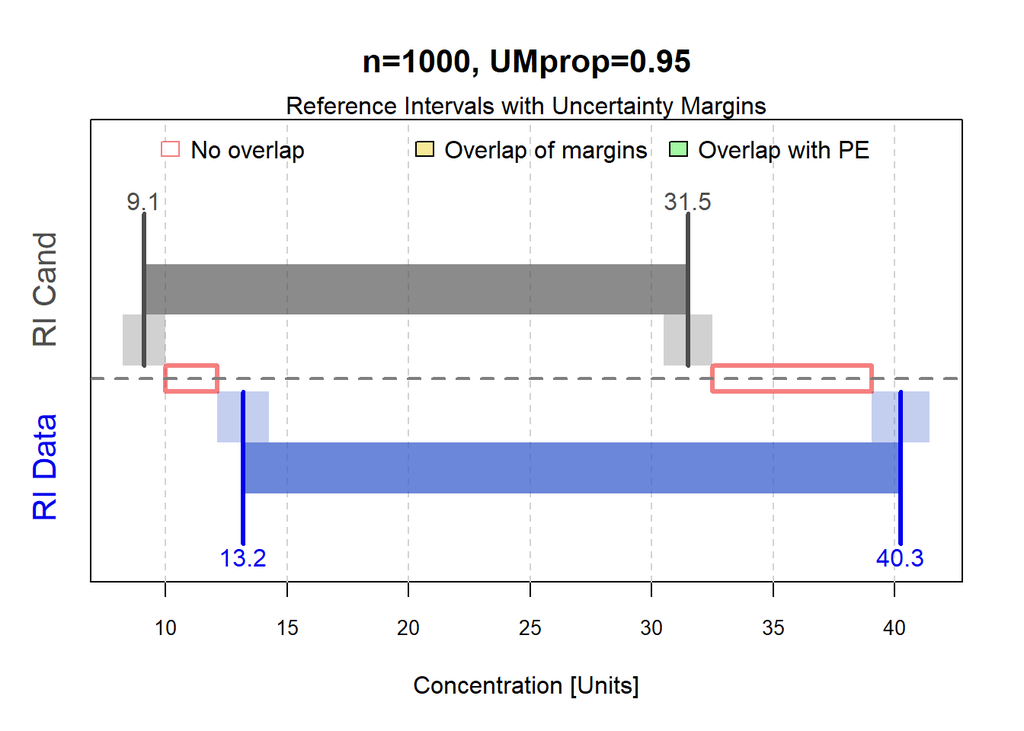

By default, an asymmetry correction is applied to the uncertainty margins. This correction may be deactivated by setting the parameter *asymmetryCorr* to *FALSE*. This is only relevant for highly skewed distributions.

The *n*, *UMprop*, and *asymmetryCorr* parameters can also be set in the *getRI*, *print*, and *plot* functions.

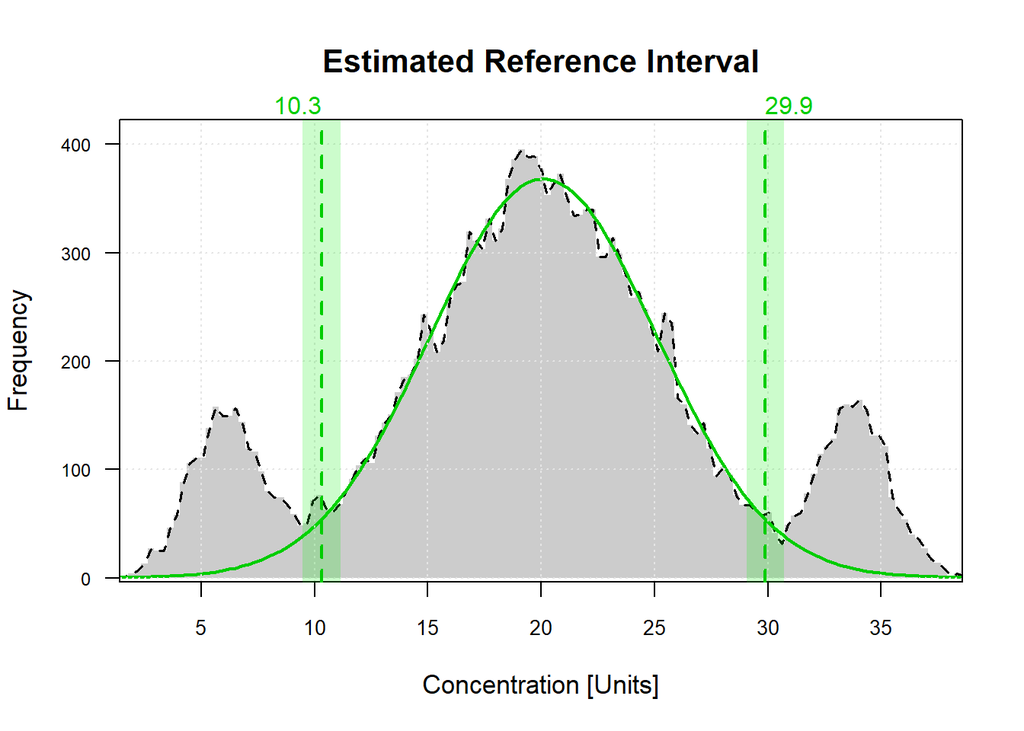

```r
plot(fit, uncertaintyRegion = "uncertaintyMargin", n = 1000, UMprop = 0.95, asymmetryCorr = TRUE)
```

```r
getRI(fit, n = 1000, UMprop = 0.95, asymmetryCorr = TRUE)
```

```
##   Percentile PointEst CILow CIHigh     UMLow   UMHigh
## 1      0.025 10.31456    NA     NA  9.487822 11.14130
## 2      0.975 29.88833    NA     NA 29.061590 30.71507
```

```r
print(fit, uncertaintyRegion = "uncertaintyMargin", n = 1000, UMprop = 0.95, asymmetryCorr = TRUE)
```

```
##
## Estimated Reference Interval
## ------------------------------------------------
## lower limit [ 2.5%]: 10.3 (9.49; 11.1)
## upper limit [97.5%]: 29.9 (29.1; 30.7)
##
## Width of the uncertainty margin [n = 1000]: 95%
##
## Model Parameters
## ------------------------------------------------
##      method: refineR (v2.0.0)
##       model: BoxCox
##      N data: 10000
##     rounded: no
##   point est: fullDataEst
## uncertainty: uncertaintyMargin
##      lambda: 1
##          mu: 19.1
##       sigma: 4.99
##       shift: 0
##        cost: -25.6
## NP fraction: 0.803
```

### Customization of the Plot

The plot of *verifyRI* can be customized by setting the parameters:

- *xlab* (character) The label of the x-axis.
- *title* (character) The title of the plot.
- *Scale* (character) The scale of the x-axis. Possible values are “original”, “splitXAxis”, and “transformed”. Default is “original”.
- *candLabel* (character) The label for the candidate reference interval.
- *dataLabel* (character) The label for the local reference interval.

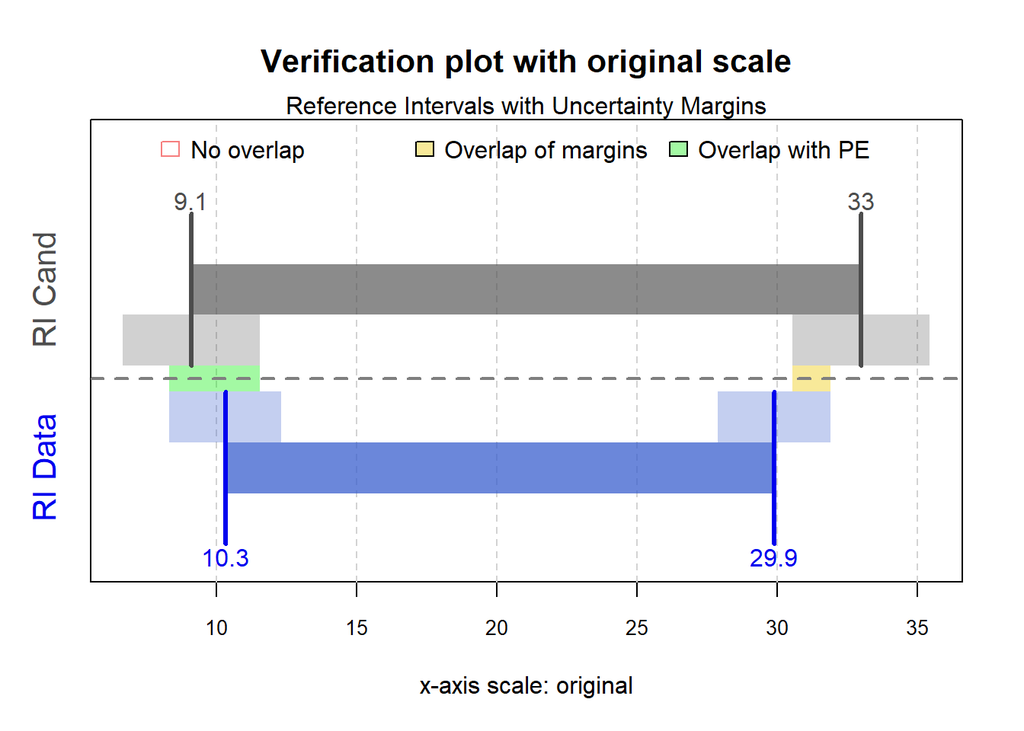

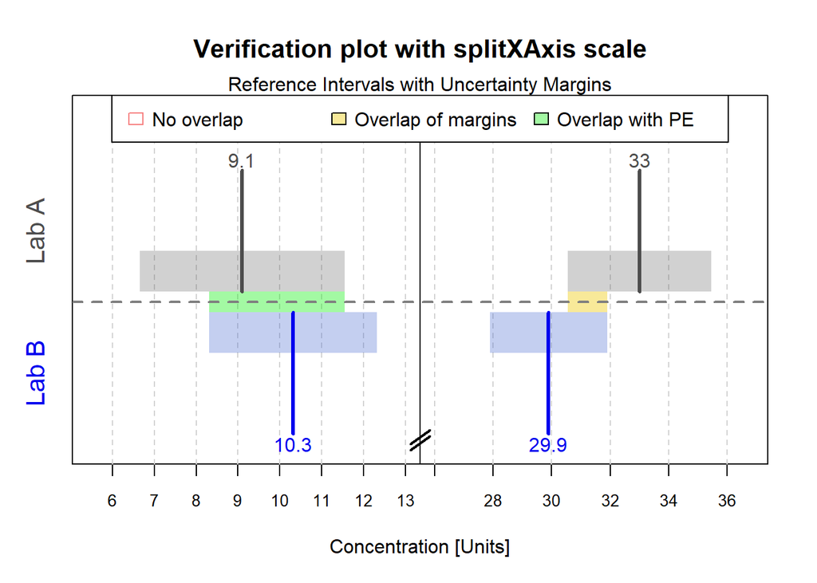

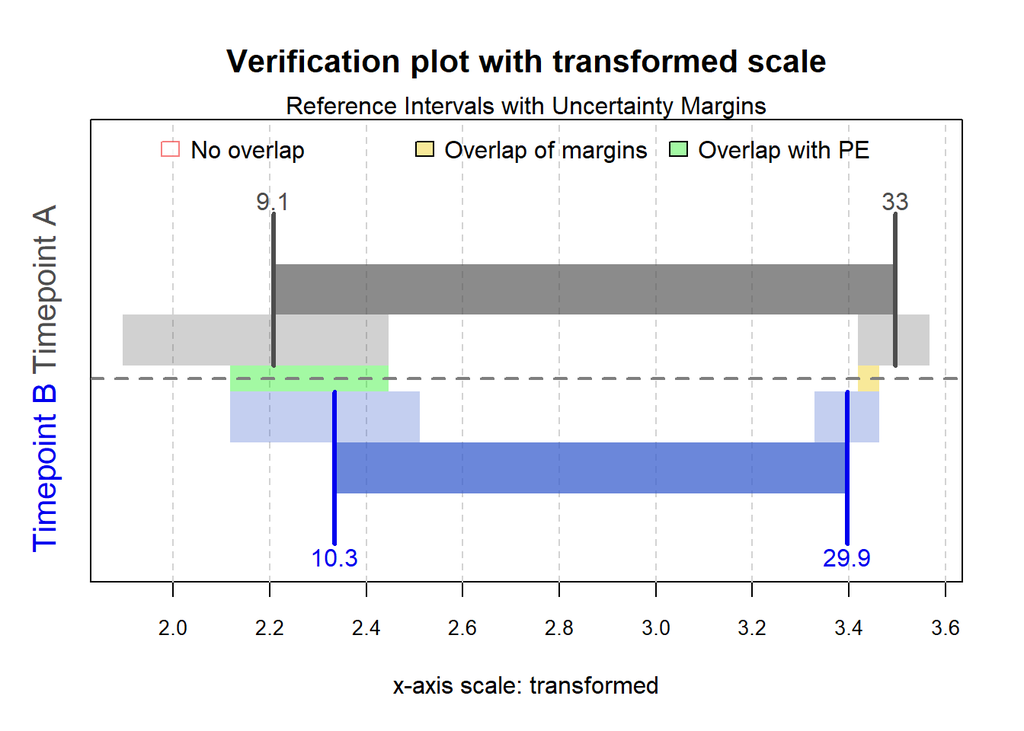

```r
scaleOptions <- c("original", "splitXAxis", "transformed")
labels <- c("default", "Laboratory", "Timepoint")
for(i in 1:3) {

if(i == 1){
  candLabel <- dataLabel <- NULL
}
if(i == 2){
  candLabel <- "Lab A"
  dataLabel <- "Lab B"
}
if(i == 3){
  candLabel <- "Timepoint A"
  dataLabel <- "Timepoint B"
}

  verifyRI(
    RIdata = fit, RIcand = c(9.1, 33), printResults = FALSE,
    xlab = paste("x-axis scale:", scaleOptions[i]),
    title = paste("Verification plot with", scaleOptions[i], "scale"),
    Scale = scaleOptions[i],
    candLabel = candLabel,
    dataLabel = dataLabel
  )
}
```

### Advanced Parameters for *getRISimilarity*

The *getRISimilarity* function can be customized with the following parameters:

- *UMprop* (numeric) The desired confidence level for the uncertainty margins. Default is 0.9 (90% confidence interval).
- *asymmetryCorr* (logical) If TRUE, an asymmetry correction is applied to the uncertainty margins. Default is TRUE.
- *Overlap* (*character*) either “OverlapMargins” (uncertainty margins overlap) or “OverlapPointEst” (point estimates are within uncertainty margins). Default is “OverlapMargins”

```r
# Suppose the currently used reference interval is [9.1, 55]
getRISimilarity(RIdata = fit, RIcand = c(9.1, 55), UMprop = 0.95, asymmetryCorr = FALSE, Overlap = "OverlapPointEst")
```

```
##
## Similarity Table
## ----------------
##
## Perc  | RI Data | RI Cand | Max Sample Size* | S-Value
## ----- | ------- | ------- | ---------------- | -------
##  2.5% |    10.3 |     9.1 |              463 |   0.013
## 97.5% |    29.9 |      55 |           n < 25 |  > 0.24
##
##
## *Higher sample sizes indicate greater similarity between the reference limits.
```

### Alternative Verification Method

Haeckel et al. proposed using **Equivalence Limits** [https://doi.org/10.1515/labmed-2016-0002] to verify reference intervals. Equivalence Limits can be applied by setting the parameter *marginType* to *EL*.

```r
verifyRI(
  RIdata = fit, RIcand = c(9.1, 33), printResults = TRUE,
  marginType = "EL",
  title = "Verification with Equivalence Limits"
)
```

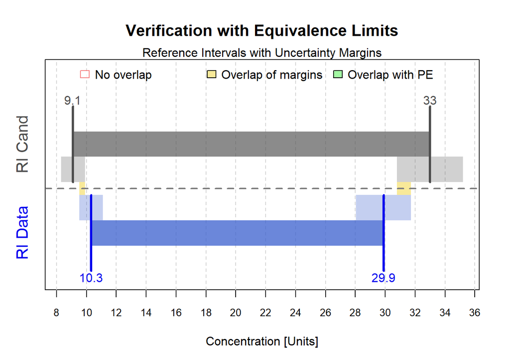

```
##
##  Verification of Reference Interval [EL]
## ---------------------------------------
##
## Verification result: TEST PASSED (all uncertainty margins overlap)
##
## Perc  | RI Data           | RI Cand          | Overlap
## ----- | ----------------- | ---------------- | ------------------
##  2.5% | 10.3 (9.53; 11.1) | 9.1 ( 8.3;  9.9) | Overlap of margins
## 97.5% | 29.9 (  28; 31.7) |  33 (30.8; 35.2) | Overlap of margins
##
##
## Fraction of data within/outside of reference interval:
## Interval | Reference Limits | Below | Within | Above
## -------- | ---------------- | ----- | ------ | -----
##  RI Data |    [10.3 , 29.9] | 12.2% |  76.0% | 11.8%
##  RI Cand |    [ 9.1 ,   33] | 10.9% |  81.4% |  7.7%
```

## References

Beck, M., Dufey, F., Ammer, T., Schützenmeister, A., Zierk, J., Rank, C. M., & Rauh, M. (2025). VeRUS: verification of reference intervals based on the uncertainty of sampling. Clinical Chemistry and Laboratory Medicine. https://doi.org/10.1515/cclm-2025-0728.

Ammer, T., Schuetzenmeister, A., Rank, C.M., Doyle, K. Estimation of Reference Intervals from Routine Data Using the refineR Algorithm — A Practical Guide. The Journal of Applied Laboratory Medicine, 8(1):84-91 (2023). https://doi.org/10.1093/jalm/jfac101.

Haeckel, Rainer, Wosniok, Werner and Arzideh, Farhad. Equivalence limits of reference intervals for partitioning of population data. Relevant differences of reference limits. LaboratoriumsMedizin. 40(3):199-205 (2016). https://doi.org/10.1515/labmed-2016-0002.